# R Notebook

```r
library(tidyverse)
library(janitor)
```

# Question 1.

Load the data, clean_names() and explore it.

```r
mobile_ratings <- read_csv("data/20190928-items.csv") %>%
  clean_names()
mobile_ratings
```

| asin | brand | title | url | image | rating | review_url | total_reviews | prices |
| --- | --- | --- | --- | --- | --- | --- | --- | --- |
| B0000SX2UC | Nokia | Dual-Band / Tri-Mode Sprint PCS Phone w/ Voice Activated Dialing & Bright White Backlit Screen | https://www.amazon.com/Dual-Band-Tri-Mode-Activated-Dialing-Backlit/dp/B0000SX2UC | https://m.media-amazon.com/images/I/2143EBQ210L._AC_UY218_SEARCH213888_FMwebp_QL75_.jpg | 3.0 | https://www.amazon.com/product-reviews/B0000SX2UC | 14 | NA |
| B0009N5L7K | Motorola | Motorola I265 phone | https://www.amazon.com/Motorola-i265-I265-phone/dp/B0009N5L7K | https://m.media-amazon.com/images/I/419WBAVDARL._AC_UY218_SEARCH213888_FMwebp_QL75_.jpg | 2.9 | https://www.amazon.com/product-reviews/B0009N5L7K | 7 | $49.95 |
| B000SKTZ0S | Motorola | MOTOROLA C168i AT&T CINGULAR PREPAID GOPHONE CELL PHONE | https://www.amazon.com/MOTOROLA-C168i-CINGULAR-PREPAID-GOPHONE/dp/B000SKTZ0S | https://m.media-amazon.com/images/I/71b+q3ydkIS._AC_UY218_SEARCH213888_FMwebp_QL75_.jpg | 2.6 | https://www.amazon.com/product-reviews/B000SKTZ0S | 22 | NA |
| B00198M12M | Nokia | Nokia 6500 Slide Black/silver Unlocked Cell Phone | https://www.amazon.com/Nokia-6500-Slide-silver-Unlocked/dp/B00198M12M | https://m.media-amazon.com/images/I/41ss4HpLkLL._AC_UY218_SEARCH213888_FMwebp_QL75_.jpg | 2.4 | https://www.amazon.com/product-reviews/B00198M12M | 5 | NA |
| B001AO4OUC | Motorola | Motorola i335 Cell Phone Boost Mobile | https://www.amazon.com/Motorola-i335-Phone-Boost-Mobile/dp/B001AO4OUC | https://m.media-amazon.com/images/I/710UO8gdT+L._AC_UY218_SEARCH213888_FMwebp_QL75_.jpg | 3.3 | https://www.amazon.com/product-reviews/B001AO4OUC | 21 | NA |
| B001DCJAJG | Motorola | Motorola V365 no contract cellular phone AT&T | https://www.amazon.com/Motorola-V365-contract-cellular-phone/dp/B001DCJAJG | https://m.media-amazon.com/images/I/61LYNCVrrKL._AC_UY218_SEARCH213888_FMwebp_QL75_.jpg | 3.2 | https://www.amazon.com/product-reviews/B001DCJAJG | 12 | NA |
| B001DZY4KI | Sony | Sony Ericsson G700 Triband GSM Phone Bronze (Unlocked) | https://www.amazon.com/Sony-Ericsson-Triband-Bronze-Unlocked/dp/B001DZY4KI | https://m.media-amazon.com/images/I/51mL10InzcL._AC_UY218_SEARCH213888_FMwebp_QL75_.jpg | 2.0 | https://www.amazon.com/product-reviews/B001DZY4KI | 1 | $78.99 |
| B001GQ3DJM | Nokia | Nokia 1680 Black Phone (T-Mobile) | https://www.amazon.com/Nokia-1680-Black-Phone-T-Mobile/dp/B001GQ3DJM | https://m.media-amazon.com/images/I/41X4VeqkFOL._AC_UY218_SEARCH213888_FMwebp_QL75_.jpg | 2.7 | https://www.amazon.com/product-reviews/B001GQ3DJM | 3 | NA |
| B0027VKQPE | Nokia | Nokia New 1100 for Tracfone | https://www.amazon.com/New-Nokia-1100-for-Tracfone/dp/B0027VKQPE | https://m.media-amazon.com/images/I/91IUe3nDP7L._AC_UY218_SEARCH213888_FMwebp_QL75_.jpg | 3.2 | https://www.amazon.com/product-reviews/B0027VKQPE | 8 | $99.99 |
| B00280QJFU | Samsung | Samsung T301G Prepaid Phone (Tracfone) | https://www.amazon.com/Samsung-T301G-Prepaid-Phone-Tracfone/dp/B00280QJFU | https://m.media-amazon.com/images/I/71QX+Kiri4L._AC_UY218_SEARCH213888_FMwebp_QL75_.jpg | 3.5 | https://www.amazon.com/product-reviews/B00280QJFU | 133 | $59.89 |

[output cut: 782 more lines]

# Question 2.

Find the brand with the highest numbers of phones in the dataset.

```r
mobile_ratings %>%
  group_by(brand) %>%
  summarise(num_phones = n()) %>%
  slice_max(num_phones)
```

| brand | num_phones |
| --- | --- |
| Samsung | 397 |

```r
NA
```

Samsung has the highest number of phones in the dataset

# Question 3.

For your top brand, plot the distribution of phone ratings as a probability density, overlaying a fitted normal distribution. Do you think the normal distribution provides a good model of these ratings?

[output not shown]

```r
library(MASS)
fitdistr(samsung_ratings$rating, densfun = "normal")
```

```
      mean          sd
  3.57329975   0.68392293
 (0.03432511) (0.02427152)
```

```r
samsung_ratings_z_scored <- samsung_ratings %>%
  mutate(z = (rating - samsung_rating_stats$mean_rating) / samsung_rating_stats$sd_rating)

# number of ratings within one sd
sr_1sd <- samsung_ratings_z_scored %>%
  filter(abs(z) <= 1) %>%
  summarise(frac = n() / nrow(samsung_ratings_z_scored)) %>%
  pull()
# 79.3%

# number of ratings within two sd
sr_2sd <- samsung_ratings_z_scored %>%
  filter(abs(z) <= 2) %>%
  summarise(frac = n() / nrow(samsung_ratings_z_scored)) %>%
  pull()
# 91.9%

# number of ratings within two sd
sr_3sd <- samsung_ratings_z_scored %>%
  filter(abs(z) <= 3) %>%
  summarise(frac = n() / nrow(samsung_ratings_z_scored)) %>%
  pull()
# 97.9%
```

```r
nd_1sd <- pnorm(q = 1) - pnorm(q = -1)
nd_2sd <- pnorm(q = 2) - pnorm(q = -2)
nd_3sd <- pnorm(q = 2) - pnorm(q = -3)
```

```r
as_tibble(
  list(
  sd = c(1,2,3),
  samsung_ratings_data = c(sr_1sd, sr_2sd, sr_3sd),
  normal_dist = c(nd_1sd, nd_2sd, nd_3sd))
)
```

| sd | samsung_ratings_data | normal_dist |
| --- | --- | --- |
| 1 | 0.7934509 | 0.6826895 |
| 2 | 0.9193955 | 0.9544997 |
| 3 | 0.9798489 | 0.9759000 |

```r
NA
```

The samsung ratings data doesn’t appear to match the proportions of data contained within the 1, 2 and 3 standard deviations. The samsung data shows a much higher proportion of the data being captured within one sd suggesting that the data is quite heavily concentrated near the mean in comparison to the normal distribution, this combined with a meaningful amount of data points at the extremes (i.e. rating of 1) is enough to effect the mean and standard deviation and the amount of data contained within the 1 standard deviation range.

# EXTENSION

Investigate the use of the qqnorm() plot in R to determine whether data is normally distributed. What is a ‘quantile-quantile plot’? What do we expect to see in a qqnorm() plot if data is nearly normally distributed?

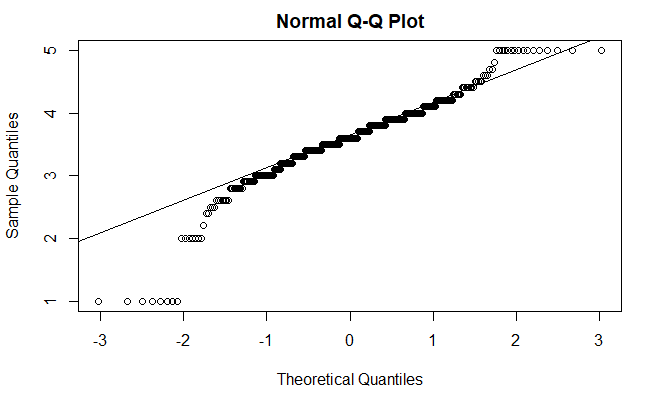

```r
qqnorm(samsung_ratings$rating)
qqline(samsung_ratings$rating)
```

The QQ-plot above shows that there is significant deviation from the Samsung rating data and normal distribution. If the the data was perfectly normal then the data (shown as circles) would follow the normal distribution line. Whilst the data appears to follow this line in the middle of the data set, there are significant differences towards the extremes, this is evident at the lower sample ratings (e.g. 1 and 2 ratings). Therefore, the QQ-plot would suggest that the data does not follow a normal distribution due to the disproportionate 1 and 2 score ratings in the dataset, also known as having “heavy tails”.

```
[1]  58 127
```

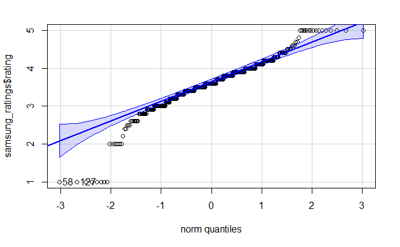

```r
qqPlot(samsung_ratings$rating)
```